# gis-ws-09-1

CoWeber, aschupp, santowsa

23 Januar 2018

# Tree Segmentation with FUSION

## Workflow:

1. Creating n-th percentile of las-point-cloud with Percentage function.
   - Is controlled by the variables “d” (percentile) and “y” (colnumber in gridmetrics csv)
2. Creating CHM with CanopyModel.exe (FUSION)

   Short description CanopyModel (FUSION):

   The CanopyModel application from FUSION creates a canopy surface model using LIDAR point cloud. Output is a  
   surfacefile in DTM format. The tool uses the returns with the highest elevation to compute the surface model. The applied /ground switch produces a canopy height model (CHM) by subtraction the earth surface model from the return elevation. The switch /gridxy: is not kept variable because the setup of the variable did not work. The CHM is required as input for the FUSION TreeSeq tool (McGaughey 2006).
3. Creating tree segmentation with TreeSeg.exe (FUSION)

### ETA: 11:39 min to calculate

## Code:

```r
mainDir <- "E:/Master/gis_09/"
inDir <- "input/"
outDir <- "output/"
results<-"results/"
Fusion<-"E:/gIs/FUSION/"
library(sp)
library(raster)
library(rgdal)

i1=list.files(paste0(mainDir,inDir),pattern=".las$", full.names=FALSE)
d=80          #d=value equal to gridmetrics colnumber
y=c(35)       #y=value in gridmetrics colnumber
h=c(1,3,10)   #h=cellsize

### 1. Percentage function ###
Percentage=function(laslist,d,y){
  for (i in laslist){
    system(paste0(Fusion,"catalog.exe ",mainDir,inDir,i," ",
                  mainDir,outDir,i,".html"))
    extent<-read.csv(paste0(mainDir,outDir,i,".csv"))
    system(paste0(paste0(Fusion,"clipdata.exe"," /class:2 ",
                         mainDir,inDir,i," ",
                         mainDir,outDir,i,"_groundpts.las "),
                  paste(extent$MinX,extent$MinY,extent$MaxX,extent$MaxY)))
    system(paste0(Fusion,"gridsurfacecreate.exe ",
                  mainDir,outDir,i,"_gridsurf.dtm "
                  ,"1 M M 1 32 0 0 ",mainDir, outDir,i,"_groundpts.las"))
    system(paste0(Fusion,"gridmetrics.exe ",mainDir,outDir,i,"_gridsurf.dtm ",0," " ,
                  1," ",mainDir,results,i,"_stattab.csv ",mainDir,inDir,i))
    for (j in y){
      system(paste0(Fusion,"csv2grid.exe ",mainDir,results,i,
                    "_stattab_all_returns_intensity_stats.csv ",j," ",mainDir,results,i,"_",d,"perc.asc"))
      tempo=raster(paste0(mainDir,results,i,"_",d, "perc.asc"))
      ex=extent(c(477248, 477468, 5631722,5631891))
      ras_crop <- crop(tempo,ex)
      projection(ras_crop) <- CRS("+init=epsg:25832")
      writeRaster(ras_crop,paste0(mainDir,results,i,"_",d,"perc."),format="GTiff")
    }
  }
}

### 2. CHM function ###
CanopyHeightModel=function(laslist,h){
  for (i in laslist){
    for (j in h){
      system(paste0(Fusion, "CanopyModel.exe ","/ground:",mainDir,outDir,i,"_gridsurf.dtm ", #/ground ground value for CM
                    "/gridxy:477248,5631722,477468,5631891 ", #/gridxy creates new extension values for the .DTM
                    mainDir,results,i,"_",j,"m_CHM.dtm ",j," M M 1 32 0 0 ",mainDir,inDir,i)) #j(h)= cellsize value
      system(paste0(Fusion,"DTM2ASCII.exe ",mainDir,results,i,"_",j,"m_CHM.dtm ",mainDir,results,i,"_",j,"m_CHM.asc"))
      tempo=raster(paste0(mainDir,results,i,"_",j, "m_CHM.asc"))
      projection(tempo) <- CRS("+init=epsg:25832")
      writeRaster(tempo,paste0(mainDir,results,i,"_",j,"m_CHM."),format="GTiff")
    }
  }
}

### 3. TreeSeg function ###
TreeSeg=function(laslist,h,d){
  for (i in laslist){
    for (j in h){
      system(paste0(Fusion, "TreeSeg.exe ","/shape ", # watershed algorithm # /shape: output .shp basin maps
                    mainDir,results,i,"_",j,"m_CHM.dtm ",mainDir,results,i,"_",d,"perc.tif ", # Input CHM .dtm, n-th percentile
                    mainDir,results,i,"_",j, "_treeseg_",d,"perc.csv ")) # output .csv with basin data
      tempo=raster(paste0(mainDir,results,i,"_",j,"_treeseg_",d,"perc", "_Basin_Map.asc"))
      projection(tempo) <- CRS("+init=epsg:25832")
      writeRaster(tempo,paste0(mainDir,results,i,"_",j,"_",d,"_Basin_Map."),format="GTiff")
      shapes <- readOGR(paste0(mainDir,results,i,"_",j,"_treeseg_",d,"perc","_Polygons.shp"))
      projection(shapes) <- CRS("+init=epsg:25832")
      writeOGR(shapes,dsn=paste0(mainDir,results,i,"_",j,"m_",d,"perc","_Polygons.", ".shp"),driver = "ESRI Shapefile",layer="treesize")
      shapes <- readOGR(paste0(mainDir,results,i,"_",j,"_treeseg_",d,"perc","_HighPoints.shp"))
      projection(shapes) <- CRS("+init=epsg:25832")
      writeOGR(shapes,dsn=paste0(mainDir,results,i,"_",j,"m_",d,"perc","_HighPoints.shp", ".shp"),driver = "ESRI Shapefile",layer="treepoint")
    }
  }
}
Percentage(laslist = i1,d=d,y=y)
CanopyHeightModel(laslist = i1,h=h)
TreeSeg(laslist = i1,h=h,d=d)
```

## Results

### Tree segmentation with 1x1m cellsize:

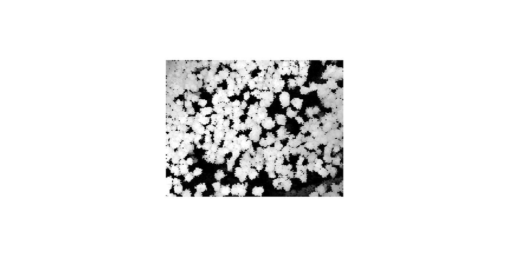

CHM 1x1

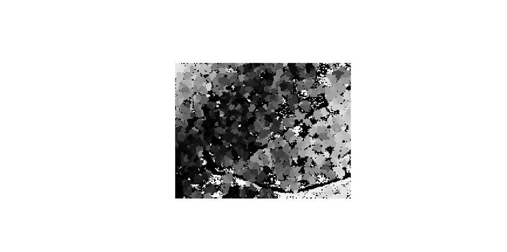

Basin model 1x1

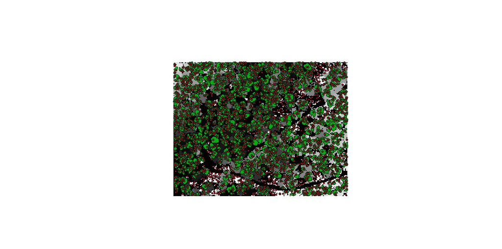

TreeSeg model with height point 1x1

### Tree segmentation with 3x3m cellsize

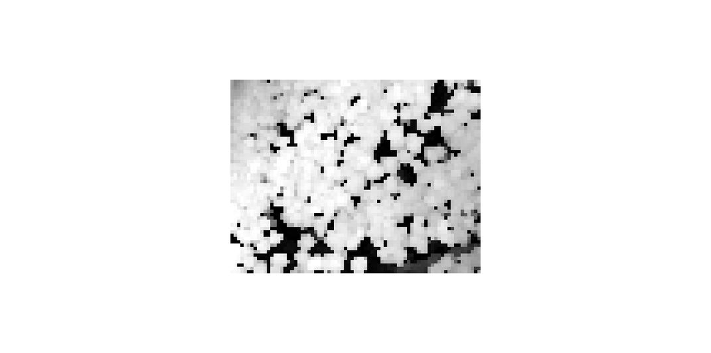

CHM 3x3

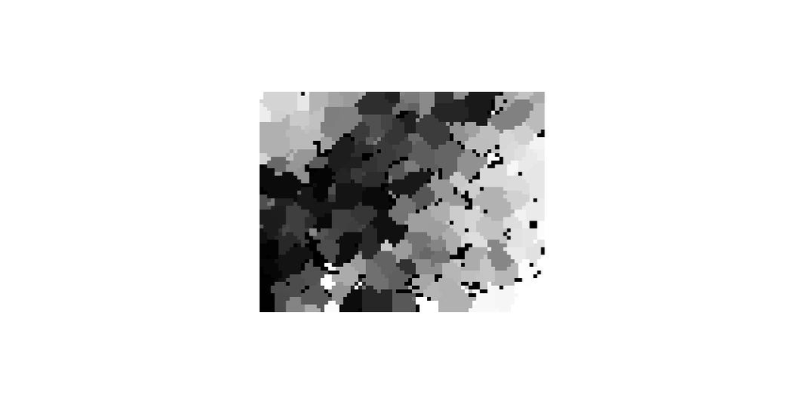

Basin model 3x3

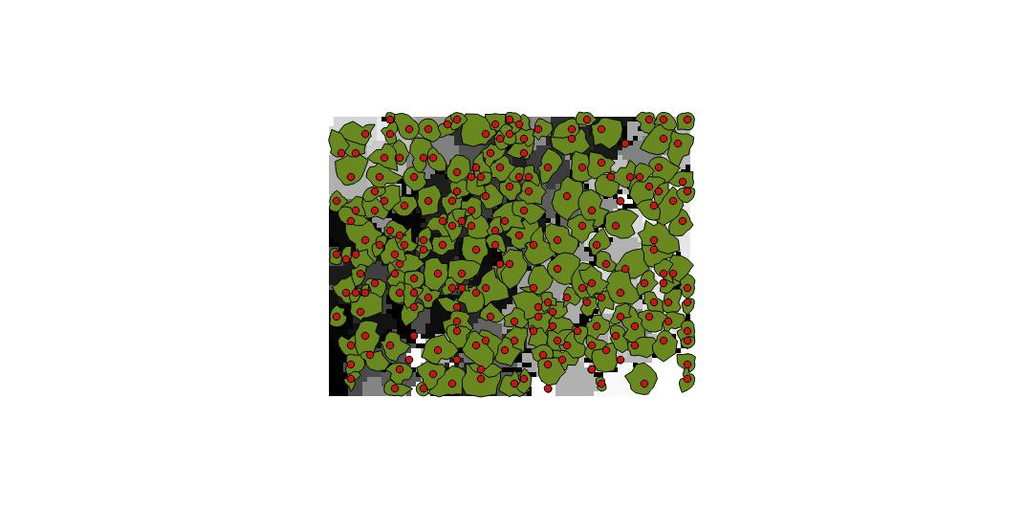

TreeSeg model with height point 3x3

### Comparison with 10x10m TreeSeg model with height points:

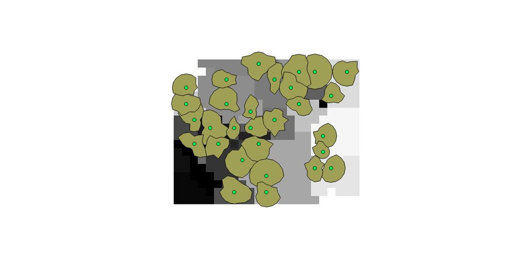

TreeSeg model with height point 10x10

## Conclusion

The first TreeSeg model with 1x1m has the best basin model in exchange with the CHM. The problem of TreeSeg.exe with dens canopy covers becomes clear here. The polygons are to small to represent the real crowns. The second model with 3x3m has average basin model and polygons, therefore should be considered as best to use. It becomes clear that the tool is very sensitve to the resolution of input data. In camparison of both models the 10x10m model shows very good polygons, but resolution (basin model) is to low, to detect single trees.